# Introduction to Japanese Economy

November 21, 2024 / This version: 2024-11-21

## The Lost Two Decades

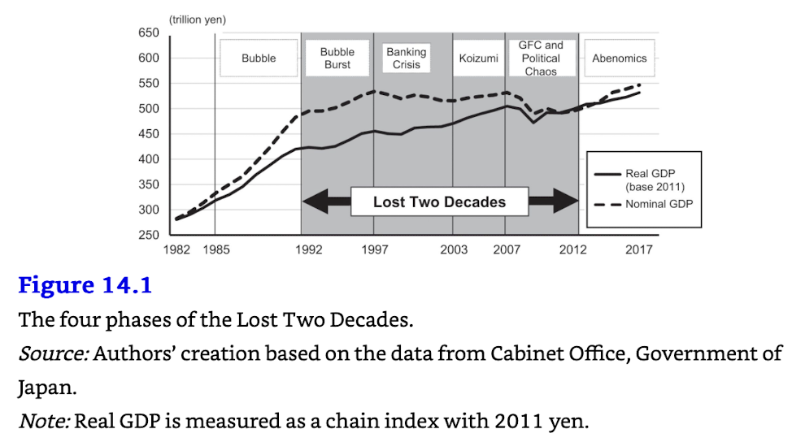

- GFC: Global Financial Crisis

## Phases 1 and 2. The bubble economy and the burst

- The bubble economy in the late 1980s was characterized by the rapid increase in asset prices, especially in the stock and real estate markets.
- The bubble burst in the early 1990s, and the asset prices plummeted.
- It resulted in the non-performing loans in the banking sector, which led to the banking crisis.
- The banks stopped lending, and the economy went into a recession.
- The government finally had to inject public funds to save the banks.

## Phase 3. Koizumi reform

- Junichiro Koizumi became the Prime Minister in 2001.
- He implemented the structural reform, including the privatization of the postal service, the reform of the pension system, and the deregulation of the economy.
- The economy started to recover, and the GDP growth rate increased.
- However, the recovery was short-lived, and the economy went back to stagnation.

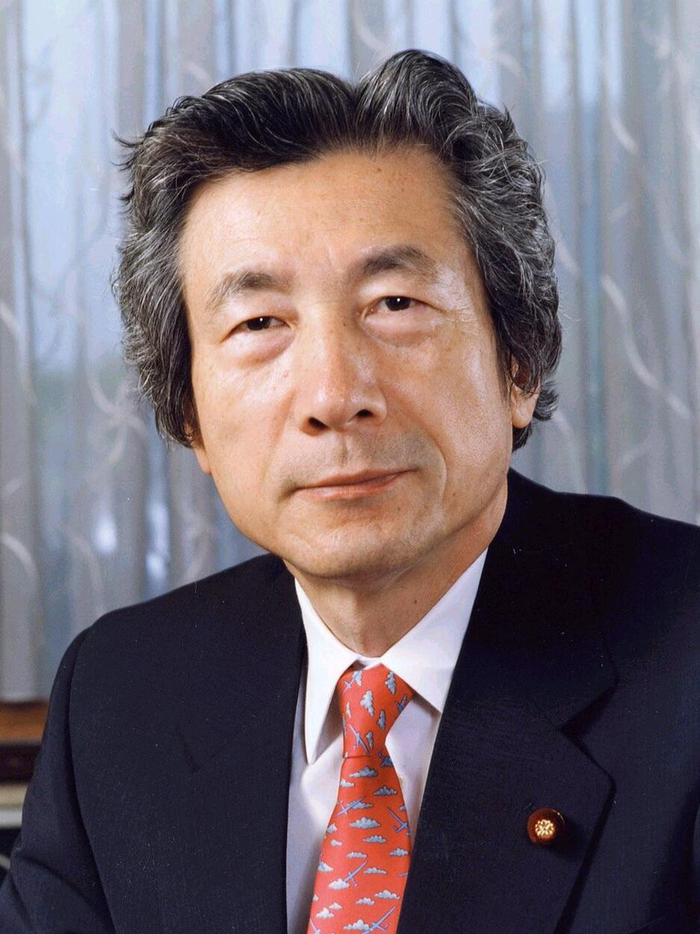

Source: [Wikipedia](https://en.wikipedia.org/wiki/Junichiro_Koizumi)

## Phase 4. Global Financial Crisis

- The global financial crisis in 2008 hit the Japanese economy hard.
- The exports to th US and other countries dropped sharply.
- As a results, the GDP growth rate plummeted, and the economy went into a recession.
- The government implemented the fiscal stimulus package, but the economy did not recover.

## Phase 5. Abenomics

- Shinzo Abe became the Prime Minister in 2012.
- He implemented the three arrows of Abenomics:
  1. monetary easing
  2. fiscal stimulus, and
  3. structural reform.
- The economy started to recover, and the GDP growth rate increased.

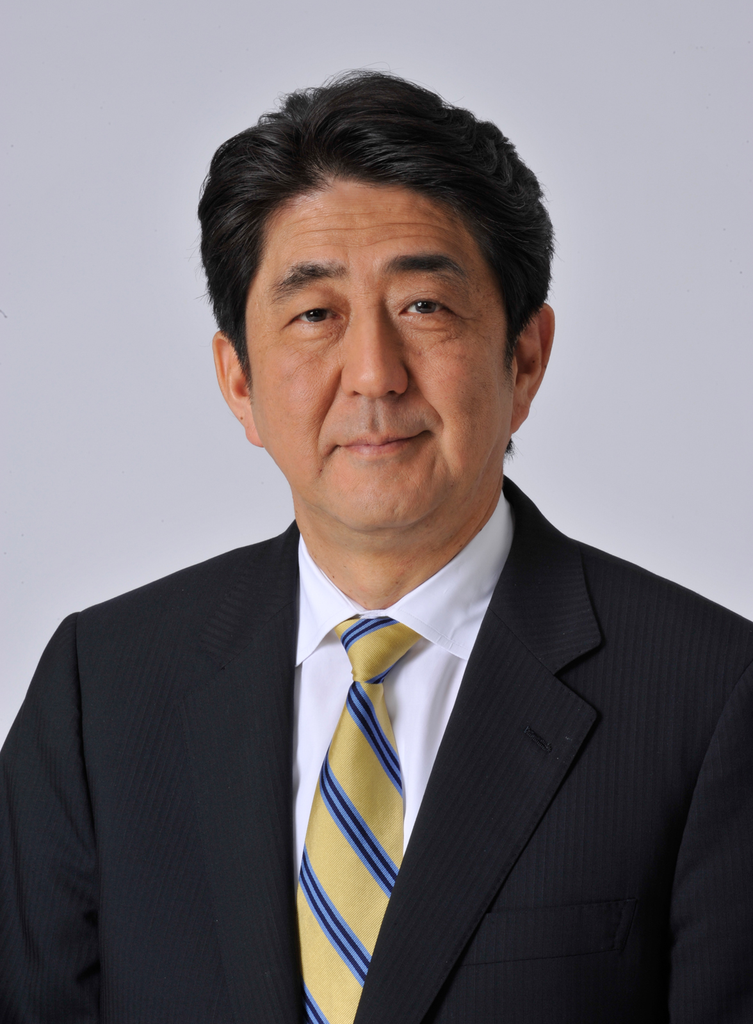

Source: [Wikipedia](https://en.wikipedia.org/wiki/Shinzo_Abe)

## What is the problem?

- In this presentation, I will discuss the following issues:
  1. The aging population
  2. The declining productivity
  3. The deflationary pressure
  4. The fiscal situation
  5. Fukushima disaster and energy policy